# Binary Classification - Chollet

## 1. Anatomy of a Neural Network:

[figure not shown]

### Tensors

Tensors are a generalization of matrices to an arbitrary number of dimensions. A tensor is a container for data—almost always numerical data.

- Scalars are 0D tensors and have 0 axes.
- Vectors are 1D tensors and have 1 axis.
- Matrices are 2D tensors with two axes (example: vector data)
- 3D tensors- timeseries data or sequence data are 3D tensors of shape (samples, timesteps, features)
- 4D tensors- Images would be 4D tensors of shape (samples, height, width, channels) or (samples, channels, height, width)
- 5D tensors- Video data of shape (samples, frames, height, width, channels) or (samples, frames, channels, height, width)

[figure not shown]

Training a neural network would revolve around the following objects:

- **Layers**, which are combined into a network (or model)
- **The input data** and corresponding targets
- **The loss function**, which defines the feedback signal used for learning
- **The optimizer**, which determines how learning proceeds

### Layers:

A layer is a data-processing module that takes as input one or more tensors and that outputs one or more tensors.

Different layers are appropriate for different tensor formats and different types of data processing. Simple vector data, stored in 2D tensors of shape (samples, features), is often processed by densely connected layers (also called fully connected or dense layers). Sequence data, stored in 3D tensors of shape (samples, timesteps, features), is typically processed by recurrent layers such as an LSTM layer. Image data, stored in 4D tensors, is usually processed by 2D convolution layers (Conv2D in Keras).

### Loss functions:

The quantity that will be minimized during training. It represents a measure of success for the task at hand.

In our example, we will be using the binary crossentropy loss, since we're dealing with a model that outputs probabilities.

### Optimizer:

Determines how the network will be updated based on the loss function. It implements a specific variant of stochastic gradient descent (SGD). A neural network that has multiple outputs may have multiple loss functions (one per output)

## 2. Classifying movie reviews: A Binary Classification example

```python
import keras
```

```python
from keras.datasets import imdb
(train_data, train_labels),(test_data, test_labels)=imdb.load_data(num_words=10000)
# only keep the top 10,000 most frequently occurring words in the training data, in order to work with data of mangaeable size
```

```python
train_data[9]
```

[output not shown]

[output cut: 75 more lines]

```
 1167,
 8,
 794,
 76,
 7,
 4,
 58,
 5,
 4,
 816,
 9,
 243,
 7,
 43,
 50]
```

```python
test_labels[23000]
```

```
0
```

```python
# since we're restricting ourself to the top 10,000 most frequent words, no word index should exceed 10,000
max([max(sequence)for sequence in train_data])
```

```
9999
```

```python
word_index=imdb.get_word_index()
reverse_word_index=dict([(value, key) for (key,value) in word_index.items()])
decoded_review=' '.join([reverse_word_index.get(i - 3,'?') for i in train_data[0]])
```

```
Downloading data from https://s3.amazonaws.com/text-datasets/imdb_word_index.json
```

```python
decoded_review
```

```
"? this film was just brilliant casting location scenery story direction everyone's really suited the part they played and you could just imagine being there robert ? is an amazing actor and now the same being director ? father came from the same scottish island as myself so i loved the fact there w…
```

```python
import numpy as np

def vectorize_sequences(sequences, dimension=10000):
    results=np.zeros((len(sequences), dimension)) # creates an all-zero matrix of shape (len(sequences), dimension)
    for i, sequence in enumerate(sequences):
        results[i,sequence]= 1. # Sets specific indices of results[i] to 1s
    return results

x_train= vectorize_sequences(train_data) # vectorized training data
x_test = vectorize_sequences(test_data) # vectorized test data
```

```python
x_train[998]
```

```
array([0., 1., 1., ..., 0., 0., 0.])
```

```python
# vectorizing our labels
y_train= np.asarray(train_labels).astype('float32')
y_test=np.asarray(test_labels).astype('float32')
```

```python
from keras import models
from keras import layers
```

```python
model=models.Sequential()
model.add(layers.Dense(16, activation="relu", input_shape=(10000, )))
model.add(layers.Dense(16, activation="relu"))
model.add(layers.Dense(1, activation="sigmoid"))
```

```python
model.compile(optimizer='rmsprop',
             loss='binary_crossentropy',
             metrics=['accuracy'])
```

```python
# setting apart 10,000 samples from the original training data to make a validation set
x_val = x_train[:10000]
partial_x_train= x_train[10000:]

y_val = y_train[:10000]
partial_y_train = y_train[10000:]
```

```python
history= model.fit(partial_x_train,
                  partial_y_train,
                  epochs=20,
                  batch_size=512,
                  validation_data=(x_val, y_val))
''' returns a History object. This object has a member history, which is a dictionary containing data about
everything that happened during training.
'''
```

```
Train on 15000 samples, validate on 10000 samples
```

```python
history_dict=history.history
history_dict.keys()
```

```
dict_keys(['val_loss', 'val_acc', 'loss', 'acc'])
```

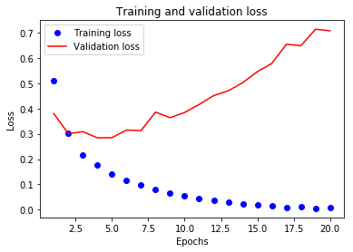

```python
import matplotlib.pyplot as plt

acc=history.history['acc']
val_acc=history.history['val_acc']
loss=history.history['loss']
val_loss=history.history['val_loss']

epochs=range(1, len(acc) +1)

plt.plot(epochs, loss, 'bo', label='Training loss')
plt.plot(epochs, val_loss, 'r', label='Validation loss')
plt.title('Training and validation loss')
plt.xlabel('Epochs')
plt.ylabel('Loss')
plt.legend()

plt.show()
```

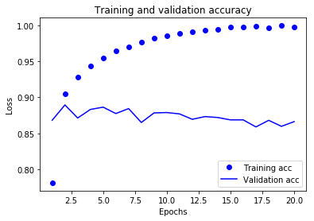

```python
plt.plot(epochs, acc, 'bo', label='Training acc')
plt.plot(epochs, val_acc, 'b', label='Validation acc')
plt.title('Training and validation accuracy')
plt.xlabel('Epochs')
plt.ylabel('Loss')
plt.legend()

plt.show()
```

```python
model = models.Sequential()
model.add(layers.Dense(16, activation='relu', input_shape=(10000,)))
model.add(layers.Dense(16, activation='relu'))
model.add(layers.Dense(1, activation='sigmoid'))

model.compile(optimizer='rmsprop',
              loss='binary_crossentropy',
              metrics=['accuracy'])

model.fit(x_train, y_train, epochs=4, batch_size=512)
results = model.evaluate(x_test, y_test)
```

```python
results
```

```
[0.28735693694114683, 0.88596]
```

```python
# to generate predictons on our test data
model.predict(x_test)
```

```
array([[0.16965508],
       [0.99941957],
       [0.71872014],
       ...,
       [0.08666617],
       [0.05291471],
       [0.42695776]], dtype=float32)
```

The network is confident for some samples (0.99 or more, or 0.01 or less) but less confident for others (0.6, 0.4)

## Further Experiments:

```python
model = models.Sequential()
model.add(layers.Dense(16, activation='relu', input_shape=(10000,)))
model.add(layers.Dense(16, activation='relu'))
model.add(layers.Dense(16, activation='relu'))
model.add(layers.Dense(1, activation='sigmoid'))

model.compile(optimizer='rmsprop',
              loss='binary_crossentropy',
              metrics=['accuracy'])

model.fit(x_train, y_train, epochs=4, batch_size=512)
results = model.evaluate(x_test, y_test)
```

```python
results
```

```
[0.30737871017456053, 0.881]
```

### 2. Changing the number of hidden units:

```python
model = models.Sequential()
model.add(layers.Dense(8, activation='relu', input_shape=(10000,)))
model.add(layers.Dense(8, activation='relu'))
model.add(layers.Dense(8, activation='relu'))
model.add(layers.Dense(1, activation='sigmoid'))

model.compile(optimizer='rmsprop',
              loss='binary_crossentropy',
              metrics=['accuracy'])

model.fit(x_train, y_train, epochs=4, batch_size=512)
results = model.evaluate(x_test, y_test)
```

```python
results
```

```
[0.4005514805984497, 0.86816]
```

```python
model = models.Sequential()
model.add(layers.Dense(32, activation='relu', input_shape=(10000,)))
model.add(layers.Dense(32, activation='relu'))
model.add(layers.Dense(32, activation='relu'))
model.add(layers.Dense(1, activation='sigmoid'))

model.compile(optimizer='rmsprop',
              loss='binary_crossentropy',
              metrics=['accuracy'])

model.fit(x_train, y_train, epochs=4, batch_size=512)
results = model.evaluate(x_test, y_test)
```

```python
results
```

```
[0.358613595328331, 0.86868]
```

### 3. Changing loss functions:

```python
model = models.Sequential()
model.add(layers.Dense(32, activation='relu', input_shape=(10000,)))
model.add(layers.Dense(32, activation='relu'))
model.add(layers.Dense(32, activation='relu'))
model.add(layers.Dense(1, activation='sigmoid'))

model.compile(optimizer='rmsprop',
              loss='mse',
              metrics=['accuracy'])

model.fit(x_train, y_train, epochs=4, batch_size=512)
results = model.evaluate(x_test, y_test)
```

```python
results
```

```
[0.12855201555609702, 0.8322]
```

### 4. Changing Activation function:

```python
model = models.Sequential()
model.add(layers.Dense(32, activation='tanh', input_shape=(10000,)))
model.add(layers.Dense(32, activation='tanh'))
model.add(layers.Dense(32, activation='tanh'))
model.add(layers.Dense(1, activation='sigmoid'))

model.compile(optimizer='rmsprop',
              loss='binary_crossentropy',
              metrics=['accuracy'])

model.fit(x_train, y_train, epochs=4, batch_size=512)
results = model.evaluate(x_test, y_test)
```

```python
results
```

```
[0.367987937438488, 0.86144]
```

# In conclusion,

[figure not shown]